# Sypase Mock - R

Tasks:

1. Characterize this population based on genetic background
2. Pick one subset of this population and derive a clinically relevant implication that this dataset can illustrate
3. Share your methodology to generate the insights in #1 and #2 (please include an example of the script(s) used)
4. Share the limitations of this data set
5. Propose areas for further exploration and identify additional data points needed to enable them

4 Files:

- Biomarkers
- ICDS
- Patients
- Therapies

**Input data/Packages**

```r
# Packages
library(tidyverse)
```

```r
library(ggplot2)
library(stats)
library(plyr)
# Input of the files
biomarkers <- read.csv("C:/Users/Kevin/Dropbox/Syapse/biomarkers.csv")
icds <- read.csv("C:/Users/Kevin/Dropbox/Syapse/icds.csv")
patients <- read.csv("C:/Users/Kevin/Dropbox/Syapse/patients.csv")
therapies <- read.csv("C:/Users/Kevin/Dropbox/Syapse/therapies.csv")

# Setting working directories
path <- "C:/Users/Kevin/Dropbox/Syapse"
setwd(path)
```

**Summary Statistics of each dataset**

Initial understanding of the dataset provides insight into the number of features that are in each dataset and frequency of repeats

```
## Biomarkers: Number of items: 9488 | Number of features: 4
```

```
##
## icds: Number of items: 109 | Number of features: 6
```

```
##
## patients: Number of items: 64196 | Number of features: 5
```

```
##
## therapies: Number of items: 37 | Number of features: 5
```

Observations:

*Patients* dataset seems to be the only dataset that has a unique set of patient ids. All other datasets have some frequency of repeat entries for the same patient.

Patient Id seems to be the only feature that is common among all of the datasets.

*Icds* & *therapies* share both patient id, diag code, and diag group features

```r
# Dimensions of the data set
summary(biomarkers)
```

```
##         id                         biomarker
##  PT-5469 :  60   KDR Q472H              : 473
##  PT-38669:  37   KDR 1416A>T            : 471
##  PT-43024:  24   KIT M541L              : 125
##  PT-10950:  23   KIT 1621A>C            : 124
##  PT-50320:  23   TYMS *447_*452delTTAAAG:  94
##  PT-13292:  22   TET2 5162T>G           :  91
##  (Other) :9299   (Other)                :8110
##                alteration.type      gene
##  Substitution          :8404   TP53   :1034
##  Deletion              : 287   KDR    :1024
##  Deletion ; Frameshift : 282   TET2   :1009
##  Complex               : 208   KRAS   : 889
##  Frameshift ; Insertion:  88   PIK3CA : 524
##  Frameshift            :  70   APC    : 384
##  (Other)               : 149   (Other):4624
```

```r
summary(icds)
```

```
##         id                     diag.group
##  PT-47761:12   Bronchus & Lung      :57
##  PT-13196: 8   Breast               :31
##  PT-46875: 6   Colon                : 8
##  PT-53646: 6   Rectosigmoid Junction: 4
##  PT-54335: 6   Pancreas             : 3
##  PT-56804: 6   Esophagus            : 2
##  (Other) :65   (Other)              : 4
##                          diag.dsc                               histo.dsc
##  Lung, upper lobe            :25   Adenocarcinoma with mixed subtypes: 3
##  Lung, lower lobe            :15   Adenocarcinoma, NOS               :58
##  Breast, NOS                 :14   Infiltrating duct carcinoma, NOS  :13
##  Breast, upper-outer quadrant: 9   Lobular carcinoma, NOS            :12
##  Lung, NOS                   : 9   Mucinous adenocarcinoma           : 5
##  Lung, overlapping lesion    : 6   None                              :16
##  (Other)                     :31   Squamous cell carcinoma, NOS      : 2
##    diag.code    histo.code
##  C341   :25   8140   :58
##  C343   :15   8500   :13
##  C509   :14   8520   :12
##  C349   : 9   None   :10
##  C504   : 9   -3     : 6
##  C348   : 6   8480   : 5
##  (Other):31   (Other): 5
```

```r
summary(patients)
```

```
##         id           gender              dob        is.deceased
##  PT-1    :    1   Female:40237   2006-11-02:   11   False:53601
##  PT-10   :    1   Male  :23959   1940-04-11:   10   True :10595
##  PT-100  :    1                  1942-11-15:   10
##  PT-1000 :    1                  1945-06-30:   10
##  PT-10000:    1                  1957-03-02:   10
##  PT-10001:    1                  1957-06-12:   10
##  (Other) :64190                  (Other)   :64135
##      deceased.dts
##  2016-03-21:   13
##  2016-09-06:   13
##  2016-09-29:   13
##  2016-10-02:   13
##  2016-10-31:   13
##  (Other)   : 7752
##  NA's      :56379
```

```r
summary(therapies)
```

```
##         id                                    med.name
##  PT-58962:11   FLUORINE-18 FLUORODEOXYGLUCOSE     : 9
##  PT-52566: 7   ARIMIDEX 1 MG PO TABS              : 2
##  PT-61350: 5   BEVACIZUMAB INFUSION               : 2
##  PT-47633: 3   CAPECITABINE 500 MG PO TABS        : 2
##  PT-56804: 3   CARBOPLATIN CHEMO INFUSION (BY AUC): 2
##  PT-49781: 2   FLUOROURACIL 500 MG/10ML IV SOLN   : 2
##  (Other) : 6   (Other)                            :18
##                         diag.code  diag.group   hist.code
##  Breast, upper-outer quadrant: 1   C18:11     Min.   :  -3
##  Cecum                       :11   C25: 7     1st Qu.:8140
##  Lung, lower lobe            : 1   C34:18     Median :8480
##  Lung, NOS                   : 4   C50: 1     Mean   :7438
##  Lung, upper lobe            :13              3rd Qu.:8480
##  Pancreas, body of           : 7              Max.   :8500
##
```

Takeaways:

**Task 2:** Datasets that provide clinical data are *icds* and *therapies* and these only contain a fraction of the patients.

# Checking quality of data

```r
any(is.na(biomarkers))
```

```
## [1] FALSE
```

```r
any(is.na(icds))
```

```
## [1] FALSE
```

```r
any(is.na(patients))
```

```
## [1] TRUE
```

```r
any(is.na(therapies))
```

```
## [1] FALSE
```

After looking at the patients dataset, it seems like deceased.dts is the only feature that has NA. This makes sense as it is only filled when is.deceased if True.

|  | id | gender | dob | is.deceased | deceased.dts |
| --- | --- | --- | --- | --- | --- |
| 1 | PT-30144 | Female | 1986-02-13 | False | NA |
| 2 | PT-8599 | Male | 1981-09-04 | False | NA |
| 3 | PT-19461 | Male | 1963-03-25 | False | NA |
| 4 | PT-16365 | Male | 1993-07-15 | False | NA |
| 5 | PT-39227 | Female | 1959-06-28 | False | NA |
| 6 | PT-33627 | Female | 1979-11-02 | False | NA |

Subsetting out biomarker feature as it is specific to the patient and not in scope with the tasks. Furthermore, running each of the datasets to only capture unique values as any duplicates would skew any insight.

```r
biomarker_only <- subset(biomarkers, select = c(id,biomarker))
biomarkers_new <- subset(biomarkers, select = -c(biomarker)) %>% distinct(id, alteration.type, gene, .keep_all= TRUE)
icds_new <- icds %>% distinct(id, diag.group, diag.dsc, histo.dsc, diag.code, histo.code, .keep_all= TRUE)
therapies_new <- therapies %>% distinct(id, med.name, diag.code, diag.group,hist.code, .keep_all= TRUE)
```

|  | id | alteration.type | gene |
| --- | --- | --- | --- |
| 1 | PT-13433 | Substitution | TET2 |
| 2 | PT-2058 | Substitution | KDR |
| 3 | PT-7790 | Substitution | KDR |
| 4 | PT-3434 | Substitution | KDR |
| 5 | PT-24009 | Substitution | KDR |
| 6 | PT-18775 | Substitution | KDR |

|  | id | diag.group | diag.dsc | histo.dsc | diag.code | histo.code |
| --- | --- | --- | --- | --- | --- | --- |
| 1 | PT-40800 | Breast | Breast, upper-outer quadrant | Lobular carcinoma, NOS | C504 | 8520 |
| 2 | PT-40465 | Breast | Breast, lower-outer quadrant | Lobular carcinoma, NOS | C505 | 8520 |
| 3 | PT-17030 | Breast | Breast, NOS | Infiltrating duct carcinoma, NOS | C509 | 8500 |
| 4 | PT-819 | Breast | Breast, NOS | Infiltrating duct carcinoma, NOS | C509 | 8500 |
| 5 | PT-819 | Breast | Breast, NOS | None | C509 | None |
| 6 | PT-32988 | Breast | Breast, upper-outer quadrant | Lobular carcinoma, NOS | C504 | 8520 |

|  | id | med.name | diag.code | diag.group | hist.code |
| --- | --- | --- | --- | --- | --- |
| 1 | PT-47633 | PEMETREXED CHEMO INFUSION | Lung, upper lobe | C34 | 8140 |
| 2 | PT-56804 | CARBOPLATIN CHEMO INFUSION (BY AUC) | Lung, upper lobe | C34 | 8140 |
| 3 | PT-56804 | FLUORINE-18 FLUORODEOXYGLUCOSE | Lung, upper lobe | C34 | 8140 |
| 4 | PT-56804 | PACLITAXEL CHEMO INFUSION | Lung, upper lobe | C34 | 8140 |
| 5 | PT-58962 | CAPECITABINE 150 MG PO TABS | Cecum | C18 | 8480 |
| 6 | PT-58962 | IRINOTECAN CHEMO INFUSION | Cecum | C18 | 8480 |

## Task 1: Characterizing the population genetically

Merging patients and biomarkers provides more data into patients that have genetic data

```r
biomarkers_patient <- merge(patients, biomarkers_new, by = c("id"))
```

After the screen for unique entries and dropping biomakers this provides us with half of the original dataset

```r
dim(biomarkers_patient)
```

```
## [1] 4151    7
```

Visualizing the frequency of genes in the population. The graph below is based on a log scale to improve visualization and was split between the patients decease status One can see that the top 4 genes that most patients in the population have are KDR, TP53, KRAS, and TET2.

- Patients with genes GNQA, SRSF2, or JAK2 are all alive
- Patients with HNF1A and KMT2A are all deceased

There seems to be more patients in the population with the genes EGFR or IDH1 alive than deceased than other genes At the bottom of the graph shows genes that had such small numbers that were interpreted with a zero.

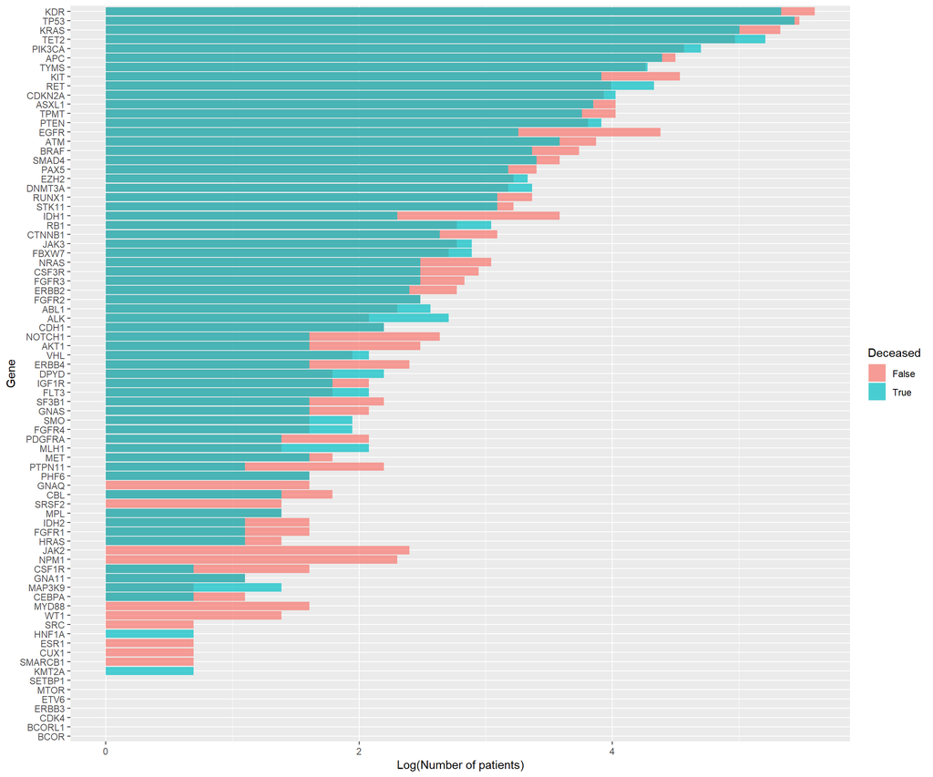

```r
y = count(biomarkers_patient, c("gene", "is.deceased"))
y$freq <- log(y$freq)
ggplot(y, aes(x = reorder(gene, freq), y = freq, fill = is.deceased)) +
  geom_bar(stat = "identity", position = "identity", alpha = 0.7) +
  coord_flip() +
  xlab("Gene") +
  ylab("Log(Number of patients)") +
  scale_fill_discrete(name = "Deceased")
```

Breaking down the alteration type within the population does show that the majority of the genes have a biomaker obtained under a substitution alteration.

There isn’t much of a difference between alternations type in regards to deceased status. But EGFR Does have a big difference in that there are many patients that are alive with a deletion biomarker. TYMS is also different from all other genes in that all of the biomarkers in that gene are obtained under deletion.

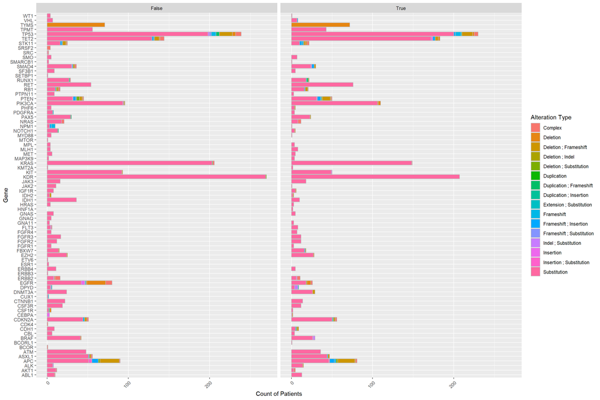

```r
y = count(biomarkers_patient, c("gene", "alteration.type", "is.deceased"))

ggplot(data = y, aes(y = freq, x = gene, fill = alteration.type)) +
  geom_bar(color = "gray", stat = "identity") +
  theme(axis.text.x = element_text(angle = 45, hjust = 1)) +
  coord_flip() +
  facet_grid(. ~ is.deceased) +
  xlab("Gene") +
  ylab("Count of Patients") +
  scale_fill_discrete(name = "Alteration Type")
```

## Task 2: Clinical Relavance

Picking a subset of this population to get a clinically relevant implication would require usage of the *therapies* and *icds* dataset Icds provides the diagnosis while the therapies provide treatment data.

```r
# switching the column names of the therapies as there are fluctuation between the features even though they contain the same data
# diag.dsc on icds matches with therapies diag.group

colnames(therapies_new) <- c("id","med.name", "diag.group", "diag.code","hist.code")
colnames(icds_new) <- c("id","diag.dsc", "diag.group", "histo.dsc","diag.code","hist.code")
icds_therapies <- merge(therapies_new, icds_new, by = c("id", "diag.group", "hist.code"))
```

```r
# Merging the icds and therapies datasets
icds_therapies_pat <- merge(icds_therapies, patients, by = c("id"))
icds_therapies_pat %>% head()
```

|  | id | diag.group | hist.code | med.name | diag.code.x | diag.dsc | histo.dsc | diag.code.y | gender | dob | is.deceased | deceased.dts |
| --- | --- | --- | --- | --- | --- | --- | --- | --- | --- | --- | --- | --- |
| 1 | PT-47633 | Lung, upper lobe | 8140 | PEMETREXED CHEMO INFUSION | C34 | Bronchus & Lung | Adenocarcinoma, NOS | C341 | Female | 1949-11-27 | False | NA |
| 2 | PT-47633 | Lung, upper lobe | 8140 | CISPLATIN CHEMO INFUSION | C34 | Bronchus & Lung | Adenocarcinoma, NOS | C341 | Female | 1949-11-27 | False | NA |
| 3 | PT-47633 | Lung, upper lobe | 8140 | FLUORINE-18 FLUORODEOXYGLUCOSE | C34 | Bronchus & Lung | Adenocarcinoma, NOS | C341 | Female | 1949-11-27 | False | NA |
| 4 | PT-47761 | Lung, lower lobe | 8140 | FLUORINE-18 FLUORODEOXYGLUCOSE | C34 | Bronchus & Lung | Adenocarcinoma, NOS | C343 | Female | 1978-01-16 | True | 2017-01-09 |
| 5 | PT-49781 | Lung, NOS | -3 | FLUORINE-18 FLUORODEOXYGLUCOSE | C34 | Bronchus & Lung | None | C349 | Female | 1971-02-20 | False | NA |
| 6 | PT-49781 | Lung, NOS | -3 | METHOTREXATE 2.5 MG PO TABS | C34 | Bronchus & Lung | None | C349 | Female | 1971-02-20 | False | NA |

```r
# Merging icds and patient dataset
icds_pat <- merge(icds_new, patients, by = c("id"))
icds_pat %>% head()
```

|  | id | diag.dsc | diag.group | histo.dsc | diag.code | hist.code | gender | dob | is.deceased | deceased.dts |
| --- | --- | --- | --- | --- | --- | --- | --- | --- | --- | --- |
| 1 | PT-11327 | Bronchus & Lung | Bronchus, main | Adenocarcinoma, NOS | C340 | 8140 | Male | 1951-02-26 | True | 2015-10-25 |
| 2 | PT-13196 | Breast | Breast, overlapping lesion | Infiltrating duct carcinoma, NOS | C508 | 8500 | Female | 1955-03-01 | False | NA |
| 3 | PT-13196 | Breast | Breast, NOS | None | C509 | None | Female | 1955-03-01 | False | NA |
| 4 | PT-14703 | Breast | Breast, NOS | Lobular carcinoma, NOS | C509 | 8520 | Female | 1977-06-10 | False | NA |
| 5 | PT-155 | Other Sites | Abdomen, NOS | None | C762 | None | Male | 1946-12-25 | True | 2016-10-30 |
| 6 | PT-155 | Colon | Sigmoid, NOS | Adenocarcinoma, NOS | C187 | 8140 | Male | 1946-12-25 | True | 2016-10-30 |

The two charts below show the differences between a subset of the population of just patients with a diagnosis and those with a diagnosis and a treatment. There doesn’t seem to be much difference between the two.

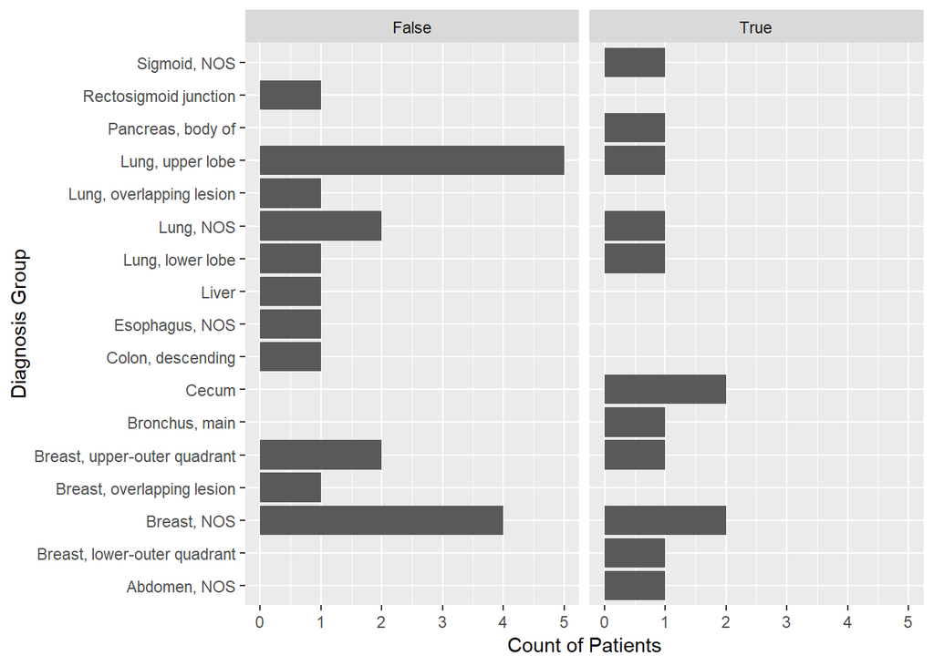

```r
ggplot(data = icds_pat, aes(x = diag.group)) +
  geom_bar() +
  coord_flip() +
  facet_grid(. ~ is.deceased) +
  xlab("Diagnosis Group") +
  ylab("Count of Patients")
```

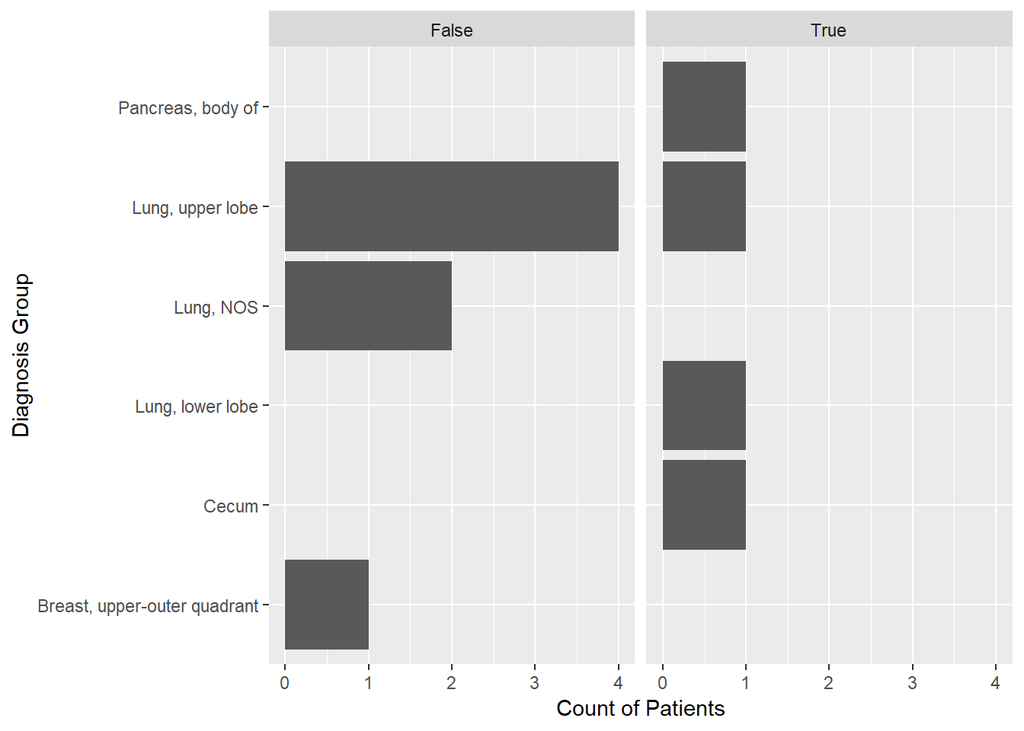

```r
icds_pat_therapies_only <- icds_therapies_pat[c("id", "diag.group","is.deceased","histo.dsc")] %>% distinct(id, diag.group,is,deceased, .keep_all= TRUE)
ggplot(data = icds_pat_therapies_only, aes(x = diag.group)) +
  geom_bar() +
  coord_flip() +
  facet_grid(. ~ is.deceased) +
  xlab("Diagnosis Group") +
  ylab("Count of Patients")
```

Vizualizing the distribution of the treatment in regards to the diagnosis location and deceased status

We can see patients in the population that have treatment to the lungs are still alive compared to patients that have had many forms of treatment for pancreas or cecum cancer

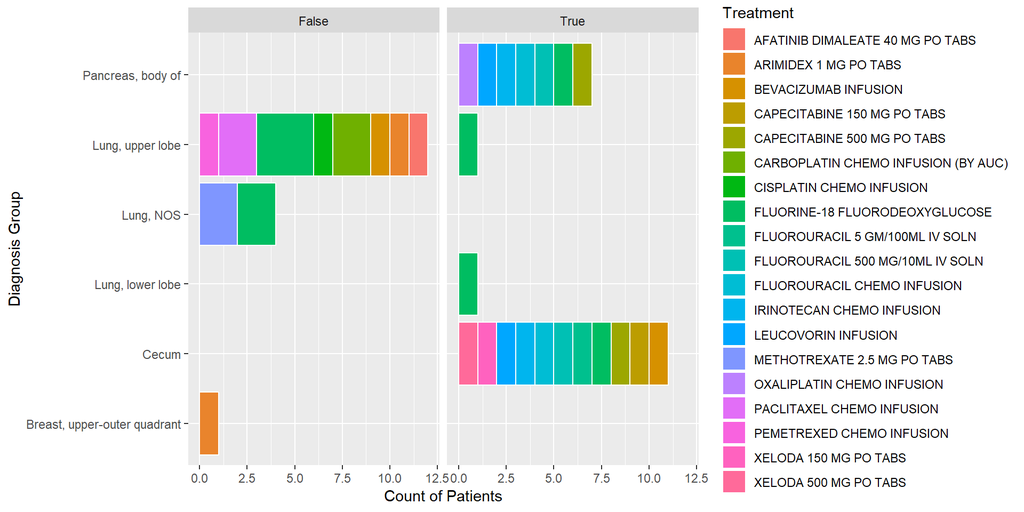

```r
ggplot(data = icds_therapies_pat, aes(x = diag.group, fill = med.name)) +
  geom_bar(color = "white") +
  coord_flip() +
  facet_grid(. ~ is.deceased) +
  xlab("Diagnosis Group") +
  ylab("Count of Patients") +
  scale_fill_discrete(name = "Treatment")
```

The following chart shows that Fluorine-18 Flurodexoyglucose is the most common treatment among majority of the group. All patients with Mucinous adenocarcinoma and treated with this were deceased compared to those without.

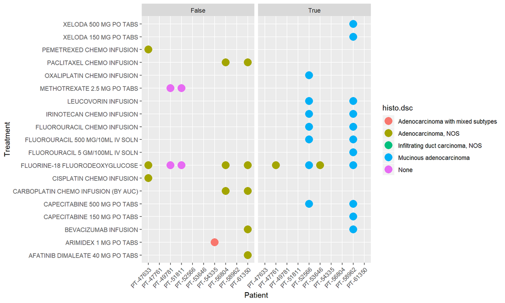

```r
ggplot(data = icds_therapies_pat, aes(x = med.name, col = histo.dsc, y = id)) +
  geom_point(size = 5) +
  coord_flip() +
  theme(axis.text.x = element_text(angle = 45, hjust = 1)) +
  facet_grid(. ~ is.deceased) +
  xlab("Treatment") +
  ylab("Patient")
```

## Insights:

Clinical Relavance:

- Most patients with breast/lung cacner are not deceased compared to those patients with pancreas/cecum cancer
- Half of the patients who are deceased underwent 2-3x more treatments than patients who are still alive.
- Fluorine-18 Flurodeoxyglucose is the most commonly used treatment among patients as well as cancer types

## Area for Exploration:

- See therapy distributions at either deceased year or at the year of treatment
- Time date from therapies needed
- Potentially seeing if there are any patients with matching biomarkers in the general population with those of current therapy patients
- Would need to link biomarkers with treatment
- Breakdown of treatment in seeing if the dosage has impact towards deceased rate
- More data to have a large enough quantity/pool to make a statisical signifance
- Breakup biomarker string to get more analysis on genome data for further characterization
- More time as to forumlate a strategy to sort out the different alternation types